# Week 9

Dr. Katz

3/16/2021

Week 9 demo - Analysis of variance (ANOVA)

## Demo 1: ANOVA with homogeneous variances

As usual, we will start with generate data to use in demos

We are going to simulate average weekly hours spent on work outside of class for students in different disciplines this means the outcome variable will be average weekly hours spent on work outside of class the factor (predictor variable) will be student major.

We will look at seven majors. Another way of saying this is that we have one factor with seven levels.

### Data generation

#### Method 1: Create a dataframe with all the descriptive stats for each group

For this approach, we will create samples directly - underlying population in this case parameterized by rnorm (so we are not creating our own population)

```r
disciplines <- c("chemical_eng", "chemistry", "biomedical_eng", "biology", "business", "architecture", "philosophy")

n <- c(50, 60, 65, 35, 50, 45, 70)
disc_mean <- c(30, 25, 28, 18, 15, 40, 19)
disc_sd <- c(3, 4, 4, 3.2, 3.8, 3.4, 4.1)


student_id <- seq(length(rep(n, n)))
student_disc <- rep(x = disciplines, n)
disc_mean_vect <- rep(disc_mean, n)
disc_sd_vect <- rep(disc_sd, n)

study_hrs <- round(modify2(.x = disc_mean_vect, .y = disc_sd_vect, .f = ~ rnorm(n = 1, mean = .x, sd= .y)), 1)

data_gen_df <- tibble(student_id, discipline = student_disc, disc_mean_vect, disc_sd_vect, study_hrs)
```

#### Method 2: Create population first and then sample from the population to create the disciplinary samples

For this method, we start with information about the populations of the different groups

```r
disciplines <- c("chemical_eng", "chemistry", "biomedical_eng", "biology", "business", "architecture", "philosophy")

pop_n <- c(1000, 1500, 1250, 1300, 1400, 1500, 1450) # create populations with different sizes
#pop_n <- rep(x = 1000, times = length(disciplines)) # assume each population is 1000 students big
pop_disc_mean <- c(30, 25, 28, 18, 15, 40, 19)
pop_disc_sd <- c(3, 4, 4, 3.2, 3.8, 3.4, 4.1)


pop_disc_name_vect <- rep(x = disciplines, times = pop_n)
pop_disc_mean_vect <- rep(x = pop_disc_mean, times = pop_n)
pop_disc_sd_vect <- rep(x = pop_disc_sd, times = pop_n)
pop_study_hrs_vect <- modify2(.x = pop_disc_mean_vect, .y = pop_disc_sd_vect, .f = ~rnorm(n = 1, mean = .x, sd = .y))


pop_data_df <- tibble(discipline = pop_disc_name_vect,
                      pop_disc_mean = pop_disc_mean_vect,
                      pop_disc_sd = pop_disc_sd_vect,
                      pop_study_hrs = pop_study_hrs_vect)
```

### Check descriptive statistics

As usual, we want to get a sense of the data we are working with, so we start with looking at descriptive stats

#### Method 1: Use group_by() and summarize()

```r
pop_data_df %>%
  group_by(discipline) %>%
  summarize(n = n(),
            mean = mean(pop_study_hrs),
            sd = sd(pop_study_hrs))
```

```
## # A tibble: 7 x 4
##   discipline         n  mean    sd
##   <chr>          <int> <dbl> <dbl>
## 1 architecture    1500  40.0  3.42
## 2 biology         1300  18.0  3.11
## 3 biomedical_eng  1250  28.0  3.98
## 4 business        1400  15.0  3.86
## 5 chemical_eng    1000  29.9  2.99
## 6 chemistry       1500  25.0  4.17
## 7 philosophy      1450  18.9  4.05
```

```r
### method 2: use describe.by()
describe.by(pop_data_df, group = "discipline")
```

```
##
##  Descriptive statistics by group
## discipline: architecture
##               vars    n mean   sd median trimmed  mad   min   max range  skew
## discipline*      1 1500  NaN   NA     NA     NaN   NA   Inf  -Inf  -Inf    NA
## pop_disc_mean    2 1500 40.0 0.00  40.00   40.00 0.00 40.00 40.00  0.00   NaN
## pop_disc_sd      3 1500  3.4 0.00   3.40    3.40 0.00  3.40  3.40  0.00   NaN
## pop_study_hrs    4 1500 40.0 3.42  39.94   40.01 3.34 28.35 50.93 22.58 -0.03
##               kurtosis   se
## discipline*         NA   NA
## pop_disc_mean      NaN 0.00
## pop_disc_sd        NaN 0.00
## pop_study_hrs     0.06 0.09
## ------------------------------------------------------------
## discipline: biology
##               vars    n  mean   sd median trimmed  mad   min   max range skew
## discipline*      1 1300   NaN   NA     NA     NaN   NA   Inf  -Inf  -Inf   NA
## pop_disc_mean    2 1300 18.00 0.00  18.00   18.00 0.00 18.00 18.00  0.00  NaN
## pop_disc_sd      3 1300  3.20 0.00   3.20    3.20 0.00  3.20  3.20  0.00  NaN
## pop_study_hrs    4 1300 17.98 3.11  18.05   18.01 3.16  6.18 26.84 20.66 -0.1
##               kurtosis   se
## discipline*         NA   NA
## pop_disc_mean      NaN 0.00
## pop_disc_sd        NaN 0.00
## pop_study_hrs        0 0.09
## ------------------------------------------------------------
## discipline: biomedical_eng
##               vars    n  mean   sd median trimmed  mad   min   max range skew
## discipline*      1 1250   NaN   NA     NA     NaN   NA   Inf  -Inf  -Inf   NA
## pop_disc_mean    2 1250 28.00 0.00  28.00   28.00 0.00 28.00 28.00  0.00  NaN
## pop_disc_sd      3 1250  4.00 0.00   4.00    4.00 0.00  4.00  4.00  0.00  NaN
## pop_study_hrs    4 1250 27.96 3.98  27.99   27.94 3.97 14.29 42.61 28.32 0.05
##               kurtosis   se
## discipline*         NA   NA
## pop_disc_mean      NaN 0.00
## pop_disc_sd        NaN 0.00
## pop_study_hrs     0.05 0.11
## ------------------------------------------------------------
## discipline: business
##               vars    n  mean   sd median trimmed  mad   min   max range skew
```

[output cut: 30 more lines]

```
## pop_disc_mean      NaN 0.00
## pop_disc_sd        NaN 0.00
## pop_study_hrs    -0.12 0.11
## ------------------------------------------------------------
## discipline: philosophy
##               vars    n  mean   sd median trimmed  mad   min   max range  skew
## discipline*      1 1450   NaN   NA     NA     NaN   NA   Inf  -Inf  -Inf    NA
## pop_disc_mean    2 1450 19.00 0.00  19.00   19.00 0.00 19.00 19.00  0.00   NaN
## pop_disc_sd      3 1450  4.10 0.00   4.10    4.10 0.00  4.10  4.10  0.00   NaN
## pop_study_hrs    4 1450 18.86 4.05  18.71   18.87 4.18  6.11 36.76 30.65 -0.01
##               kurtosis   se
## discipline*         NA   NA
## pop_disc_mean      NaN 0.00
## pop_disc_sd        NaN 0.00
## pop_study_hrs    -0.05 0.11
```

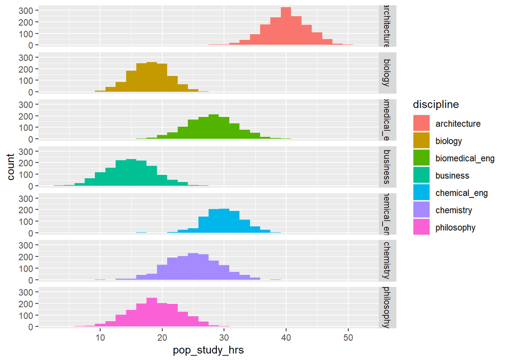

```r
# visualize the population data to make sure created correctly
pop_data_df %>%
  ggplot(aes(x = pop_study_hrs, fill = discipline)) +
  geom_histogram() +
  facet_grid(discipline ~ .)
```

### Draw samples from populations

```r
samp_n <- c(50, 60, 65, 35, 50, 45, 70)

samp_size_arc <- 50
samp_size_bio <- 60
samp_size_bme <- 65
samp_size_cheg <- 35
samp_size_bus <- 50
samp_size_phi <- 45
samp_size_chem <- 70


samp_arc_df <- pop_data_df %>%
  filter(discipline == "architecture") %>%
  sample_n(samp_size_arc)

samp_bio_df <- pop_data_df %>%
  filter(discipline == "biology") %>%
  sample_n(samp_size_bio)

samp_bme_df <- pop_data_df %>%
  filter(discipline == "biomedical_eng") %>%
  sample_n(samp_size_bme)

samp_bus_df <- pop_data_df %>%
  filter(discipline == "business") %>%
  sample_n(samp_size_bus)

samp_cheg_df <- pop_data_df %>%
  filter(discipline == "chemical_eng") %>%
  sample_n(samp_size_cheg)

samp_chem_df <- pop_data_df %>%
  filter(discipline == "chemistry") %>%
  sample_n(samp_size_chem)

samp_phi_df <- pop_data_df %>%
  filter(discipline == "philosophy") %>%
  sample_n(samp_size_phi)
```

Combine the sample dfs into one main data df

```r
data_gen_df <- bind_rows(list(samp_arc_df, samp_bio_df, samp_bme_df, samp_bus_df, samp_cheg_df, samp_chem_df, samp_phi_df))


# rename pop_study_hrs to study_hrs
data_gen_df <- data_gen_df %>% rename(study_hrs = pop_study_hrs)

# round the study_hrs to one decimal place
data_gen_df <- data_gen_df %>%
  mutate(study_hrs = round(study_hrs, 1))
```

Visualize the data

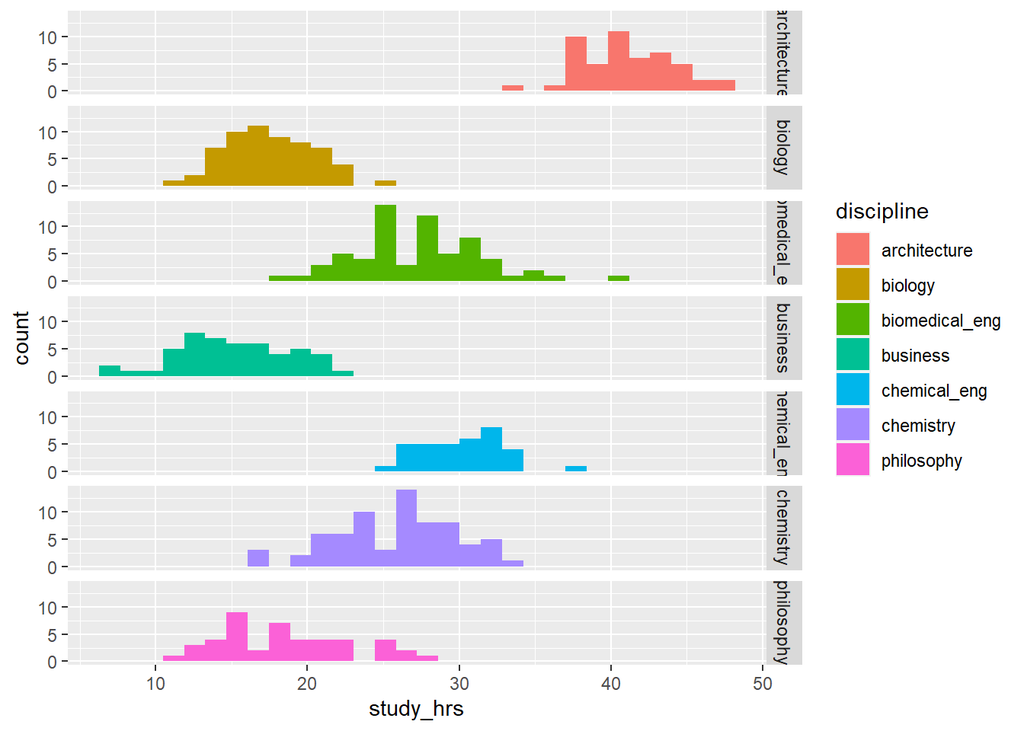

```r
data_gen_df %>%
  ggplot(aes(x = study_hrs, fill = discipline)) +
  geom_histogram() +
  facet_grid(discipline ~ .)
```

We could also look at first-year, second-year, third-year, and fourth-year. This would mean that we have a second factor with four levels.

With the data that we have, we will now do some exploratory work (mostly visualizing and looking at descriptive statistics)

```r
describe(data_gen_df)
```

```
##               vars   n  mean   sd median trimmed  mad  min  max range  skew
## discipline*      1 375   NaN   NA     NA     NaN   NA  Inf -Inf  -Inf    NA
## pop_disc_mean    2 375 24.81 7.71   25.0   24.15 8.90 15.0 40.0  25.0  0.62
## pop_disc_sd      3 375  3.68 0.39    3.8    3.72 0.44  3.0  4.1   1.1 -0.53
## study_hrs        4 375 24.92 8.83   24.4   24.34 9.04  6.8 47.3  40.5  0.49
##               kurtosis   se
## discipline*         NA   NA
## pop_disc_mean    -0.49 0.40
## pop_disc_sd      -1.36 0.02
## study_hrs        -0.44 0.46
```

To look at output by level of the discipline factor, we have a few options…

Method 1: use describe.by() from the psych package

```r
describe.by(x = data_gen_df, group = "discipline")
```

```
##
##  Descriptive statistics by group
## discipline: architecture
##               vars  n  mean   sd median trimmed  mad  min  max range skew
## discipline*      1 50   NaN   NA     NA     NaN   NA  Inf -Inf  -Inf   NA
## pop_disc_mean    2 50 40.00 0.00   40.0   40.00 0.00 40.0 40.0   0.0  NaN
## pop_disc_sd      3 50  3.40 0.00    3.4    3.40 0.00  3.4  3.4   0.0  NaN
## study_hrs        4 50 41.07 2.97   40.6   40.99 3.26 33.2 47.3  14.1 0.07
##               kurtosis   se
## discipline*         NA   NA
## pop_disc_mean      NaN 0.00
## pop_disc_sd        NaN 0.00
## study_hrs        -0.26 0.42
## ------------------------------------------------------------
## discipline: biology
##               vars  n  mean   sd median trimmed  mad  min  max range skew
## discipline*      1 60   NaN   NA     NA     NaN   NA  Inf -Inf  -Inf   NA
## pop_disc_mean    2 60 18.00 0.00  18.00   18.00 0.00 18.0 18.0   0.0  NaN
## pop_disc_sd      3 60  3.20 0.00   3.20    3.20 0.00  3.2  3.2   0.0  NaN
## study_hrs        4 60 17.55 2.88  17.35   17.51 3.11 11.8 24.7  12.9 0.09
##               kurtosis   se
## discipline*         NA   NA
## pop_disc_mean      NaN 0.00
## pop_disc_sd        NaN 0.00
## study_hrs        -0.66 0.37
## ------------------------------------------------------------
## discipline: biomedical_eng
##               vars  n  mean   sd median trimmed mad  min  max range skew
## discipline*      1 65   NaN   NA     NA     NaN  NA  Inf -Inf  -Inf   NA
## pop_disc_mean    2 65 28.00 0.00   28.0    28.0   0 28.0 28.0   0.0  NaN
## pop_disc_sd      3 65  4.00 0.00    4.0     4.0   0  4.0  4.0   0.0  NaN
## study_hrs        4 65 27.31 4.13   27.4    27.2   4 17.6 39.9  22.3 0.33
##               kurtosis   se
## discipline*         NA   NA
## pop_disc_mean      NaN 0.00
## pop_disc_sd        NaN 0.00
## study_hrs         0.23 0.51
## ------------------------------------------------------------
## discipline: business
##               vars  n  mean   sd median trimmed  mad  min  max range  skew
```

[output cut: 30 more lines]

```
## pop_disc_mean      NaN 0.00
## pop_disc_sd        NaN 0.00
## study_hrs        -0.55 0.47
## ------------------------------------------------------------
## discipline: philosophy
##               vars  n  mean   sd median trimmed  mad  min  max range skew
## discipline*      1 45   NaN   NA     NA     NaN   NA  Inf -Inf  -Inf   NA
## pop_disc_mean    2 45 19.00 0.00   19.0   19.00 0.00 19.0 19.0     0  NaN
## pop_disc_sd      3 45  4.10 0.00    4.1    4.10 0.00  4.1  4.1     0  NaN
## study_hrs        4 45 18.64 4.29   18.3   18.44 4.89 11.6 27.6    16 0.37
##               kurtosis   se
## discipline*         NA   NA
## pop_disc_mean      NaN 0.00
## pop_disc_sd        NaN 0.00
## study_hrs        -0.95 0.64
```

Method 2: use summarize() from tidyverse to create a much sparser version with only select descriptive stats

```r
data_gen_df %>%
  group_by(discipline) %>%
  summarize(n = n(),
            mean = mean(study_hrs),
            sd = sd(study_hrs))
```

```
## # A tibble: 7 x 4
##   discipline         n  mean    sd
##   <chr>          <int> <dbl> <dbl>
## 1 architecture      50  41.1  2.97
## 2 biology           60  17.5  2.88
## 3 biomedical_eng    65  27.3  4.13
## 4 business          50  15.1  3.76
## 5 chemical_eng      35  30.3  2.72
## 6 chemistry         70  25.9  3.93
## 7 philosophy        45  18.6  4.29
```

Next, let’s say we want to visualize the outcome variable distribution

Method 1: histogram

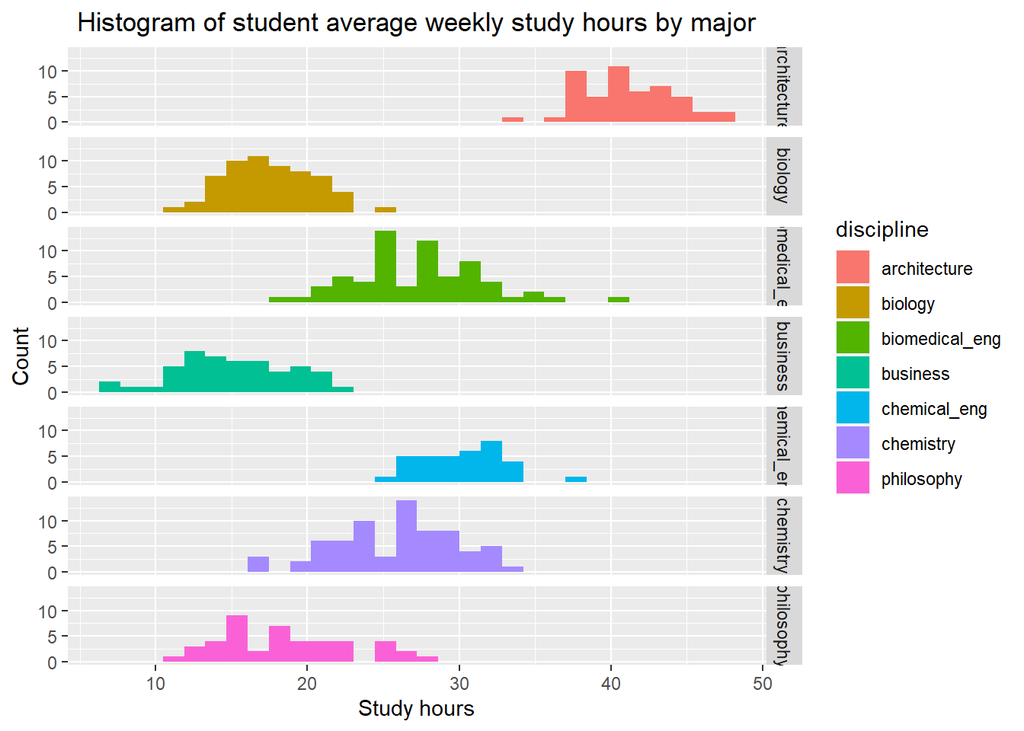

```r
data_gen_df %>%
  ggplot(aes(x = study_hrs, fill = discipline)) +
  geom_histogram() +
  facet_grid(discipline ~ .) +
  labs(title = "Histogram of student average weekly study hours by major",
       x ="Study hours",
       y = "Count") +
  theme(plot.title = element_text(hjust = 0.5))
```

Method 2: boxplots

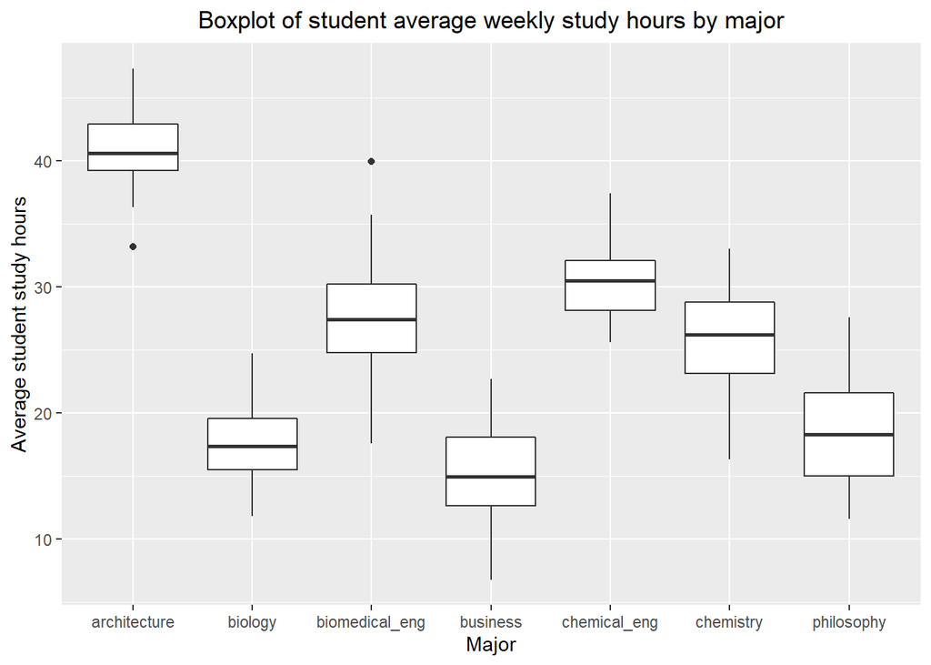

```r
data_gen_df %>%
  ggplot(aes(x = discipline, y = study_hrs)) +
  geom_boxplot() +
  labs(title = "Boxplot of student average weekly study hours by major",
       x ="Major",
       y = "Average student study hours") +
  theme(plot.title = element_text(hjust = 0.5))
```

### Running ANOVA model

First, make sure student_disc is a factor

```r
str(data_gen_df)
```

```
## tibble [375 x 4] (S3: tbl_df/tbl/data.frame)
##  $ discipline   : chr [1:375] "architecture" "architecture" "architecture" "architecture" ...
##  $ pop_disc_mean: num [1:375] 40 40 40 40 40 40 40 40 40 40 ...
##  $ pop_disc_sd  : num [1:375] 3.4 3.4 3.4 3.4 3.4 3.4 3.4 3.4 3.4 3.4 ...
##  $ study_hrs    : num [1:375] 45.8 39.2 44.4 40.3 38.3 42.7 42.5 44.3 44.1 41 ...
```

```r
data_gen_df$discipline <- as.factor(data_gen_df$discipline)
str(data_gen_df)
```

```
## tibble [375 x 4] (S3: tbl_df/tbl/data.frame)
##  $ discipline   : Factor w/ 7 levels "architecture",..: 1 1 1 1 1 1 1 1 1 1 ...
##  $ pop_disc_mean: num [1:375] 40 40 40 40 40 40 40 40 40 40 ...
##  $ pop_disc_sd  : num [1:375] 3.4 3.4 3.4 3.4 3.4 3.4 3.4 3.4 3.4 3.4 ...
##  $ study_hrs    : num [1:375] 45.8 39.2 44.4 40.3 38.3 42.7 42.5 44.3 44.1 41 ...
```

Once we have done that, we can run the model

```r
study_hrs_aov <- aov(study_hrs ~ discipline, data = data_gen_df)
summary(study_hrs_aov)
```

```
##              Df Sum Sq Mean Sq F value Pr(>F)
## discipline    6  24340    4057   309.1 <2e-16 ***
## Residuals   368   4830      13
## ---
## Signif. codes:  0 '***' 0.001 '**' 0.01 '*' 0.05 '.' 0.1 ' ' 1
```

```r
tidy(study_hrs_aov) # use this if you want to have a table of the output
```

```
## # A tibble: 2 x 6
##   term          df  sumsq meansq statistic    p.value
##   <chr>      <dbl>  <dbl>  <dbl>     <dbl>      <dbl>
## 1 discipline     6 24340. 4057.       309.  2.41e-140
## 2 Residuals    368  4830.   13.1       NA  NA
```

Plot the results of the anova

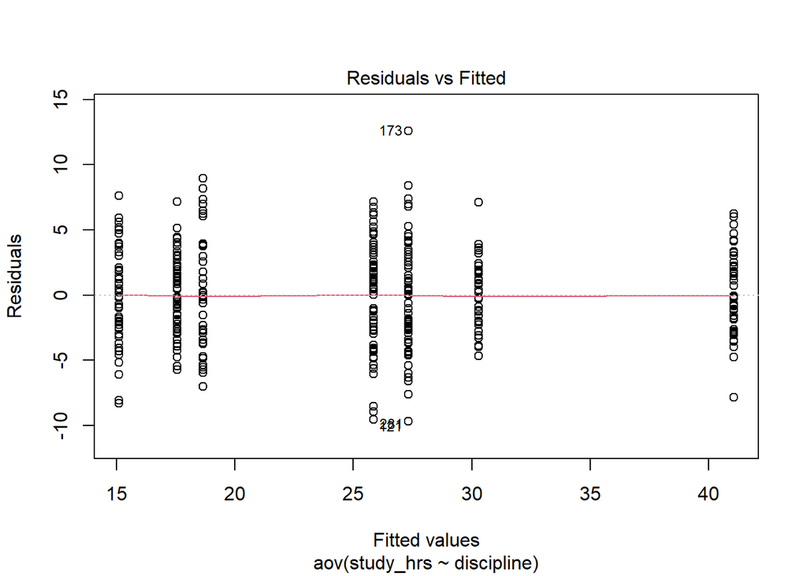

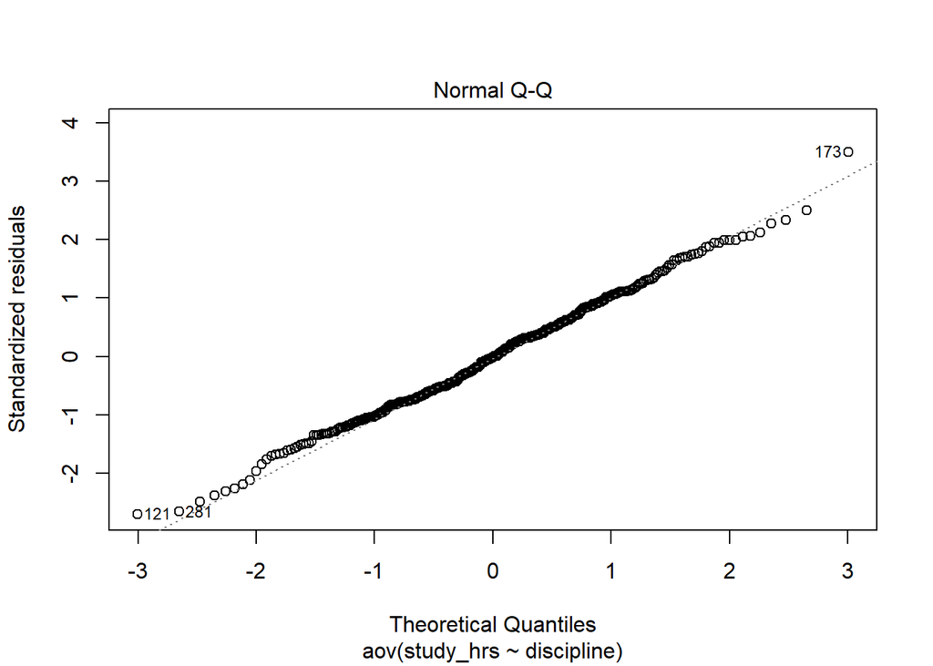

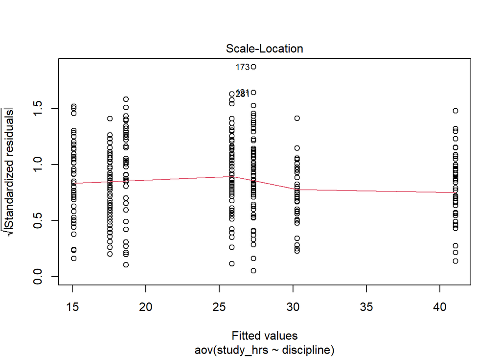

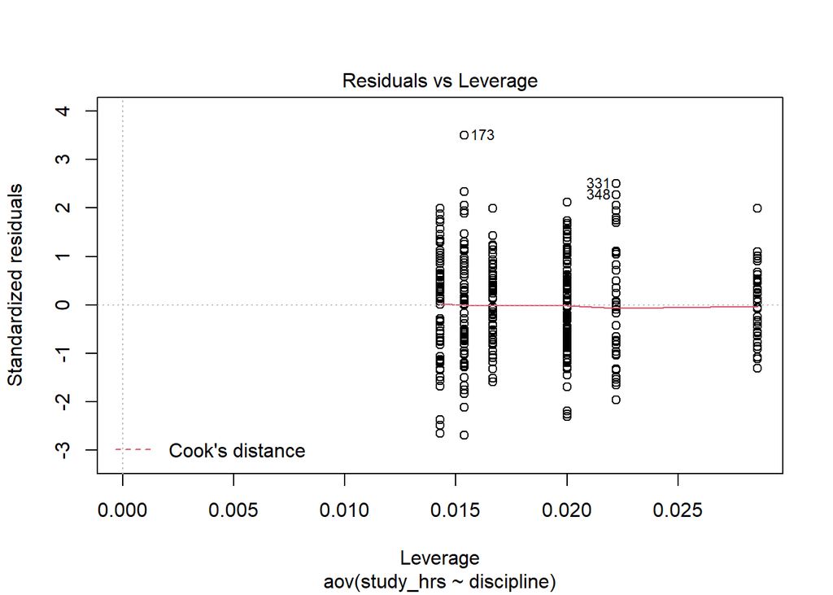

```r
plot(study_hrs_aov)
```

### Checking assumptions

Remember that the main assumptions for ANOVA are: 1. homogeneity of variance (levene’s test) To test this, we can make boxplots to quickly visualize - use plot(model) to see residuals vs fitted plot (as on p. 441)

We should also use Levene’s test of homogeneity of variances

```r
leveneTest(data_gen_df$study_hrs, data_gen_df$discipline, center = mean)
```

```
## Levene's Test for Homogeneity of Variance (center = mean)
##        Df F value   Pr(>F)
## group   6  3.0732 0.006012 **
##       368
## ---
## Signif. codes:  0 '***' 0.001 '**' 0.01 '*' 0.05 '.' 0.1 ' ' 1
```

We can use Welch’s test for scenarios of heterogeneous variances across groups (if Levene’s test failed)

```r
oneway.test(study_hrs ~ discipline, data = data_gen_df)
```

```
##
##  One-way analysis of means (not assuming equal variances)
##
## data:  study_hrs and discipline
## F = 399.47, num df = 6.00, denom df = 154.41, p-value < 2.2e-16
```

### Post hoc comparisons

In the event where the ANOVA model suggested that we can reject the null hypothesis, we then want to follow up and see which group differences were statistically significant. There are several different versions for doing this:

#### Bonferroni; Holm

Use `Use pairwise.t.test(p.adjust.method = "bonferroni")`

```r
pairwise.t.test(data_gen_df$study_hrs, data_gen_df$discipline, p.adjust.method = "bonferroni")
```

```
##
##  Pairwise comparisons using t tests with pooled SD
##
## data:  data_gen_df$study_hrs and data_gen_df$discipline
##
##                architecture biology biomedical_eng business chemical_eng
## biology        < 2e-16      -       -              -        -
## biomedical_eng < 2e-16      < 2e-16 -              -        -
## business       < 2e-16      0.0097  < 2e-16        -        -
## chemical_eng   < 2e-16      < 2e-16 0.0023         < 2e-16  -
## chemistry      < 2e-16      < 2e-16 0.4257         < 2e-16  1.7e-07
## philosophy     < 2e-16      1.0000  < 2e-16        5.8e-05  < 2e-16
##                chemistry
## biology        -
## biomedical_eng -
## business       -
## chemical_eng   -
## chemistry      -
## philosophy     < 2e-16
##
## P value adjustment method: bonferroni
```

#### Tukey and Dunnett

Let’s use Tukey’s method for our post hoc multiple comparisons

```r
post_hocs <- glht(study_hrs_aov, linfct = mcp(discipline = "Tukey"))
summary(post_hocs)
```

```
##
##   Simultaneous Tests for General Linear Hypotheses
##
## Multiple Comparisons of Means: Tukey Contrasts
##
##
## Fit: aov(formula = study_hrs ~ discipline, data = data_gen_df)
##
## Linear Hypotheses:
##                                    Estimate Std. Error t value Pr(>|t|)
## biology - architecture == 0        -23.5210     0.6938 -33.904  < 0.001 ***
## biomedical_eng - architecture == 0 -13.7568     0.6815 -20.185  < 0.001 ***
## business - architecture == 0       -25.9720     0.7246 -35.843  < 0.001 ***
## chemical_eng - architecture == 0   -10.7831     0.7985 -13.505  < 0.001 ***
## chemistry - architecture == 0      -15.2117     0.6709 -22.675  < 0.001 ***
## philosophy - architecture == 0     -22.4282     0.7445 -30.127  < 0.001 ***
## biomedical_eng - biology == 0        9.7642     0.6486  15.054  < 0.001 ***
## business - biology == 0             -2.4510     0.6938  -3.533  0.00815 **
## chemical_eng - biology == 0         12.7379     0.7706  16.530  < 0.001 ***
## chemistry - biology == 0             8.3093     0.6374  13.036  < 0.001 ***
## philosophy - biology == 0            1.0928     0.7145   1.529  0.72485
## business - biomedical_eng == 0     -12.2152     0.6815 -17.924  < 0.001 ***
## chemical_eng - biomedical_eng == 0   2.9736     0.7596   3.915  0.00195 **
## chemistry - biomedical_eng == 0     -1.4549     0.6241  -2.331  0.23022
## philosophy - biomedical_eng == 0    -8.6715     0.7026 -12.342  < 0.001 ***
## chemical_eng - business == 0        15.1889     0.7985  19.022  < 0.001 ***
## chemistry - business == 0           10.7603     0.6709  16.040  < 0.001 ***
## philosophy - business == 0           3.5438     0.7445   4.760  < 0.001 ***
## chemistry - chemical_eng == 0       -4.4286     0.7500  -5.904  < 0.001 ***
## philosophy - chemical_eng == 0     -11.6451     0.8165 -14.262  < 0.001 ***
## philosophy - chemistry == 0         -7.2165     0.6923 -10.425  < 0.001 ***
## ---
## Signif. codes:  0 '***' 0.001 '**' 0.01 '*' 0.05 '.' 0.1 ' ' 1
## (Adjusted p values reported -- single-step method)
```

```r
confint(post_hocs) # notice where there are confidence intervals that contain 0 - those should correspond to the comparisons that were not statistically significant at p < 0.05
```

```
##
##   Simultaneous Confidence Intervals
##
## Multiple Comparisons of Means: Tukey Contrasts
##
##
## Fit: aov(formula = study_hrs ~ discipline, data = data_gen_df)
##
## Quantile = 2.9608
## 95% family-wise confidence level
##
##
## Linear Hypotheses:
##                                    Estimate lwr      upr
## biology - architecture == 0        -23.5210 -25.5751 -21.4669
## biomedical_eng - architecture == 0 -13.7568 -15.7746 -11.7389
## business - architecture == 0       -25.9720 -28.1174 -23.8266
## chemical_eng - architecture == 0   -10.7831 -13.1473  -8.4190
## chemistry - architecture == 0      -15.2117 -17.1980 -13.2254
## philosophy - architecture == 0     -22.4282 -24.6324 -20.2240
## biomedical_eng - biology == 0        9.7642   7.8438  11.6847
## business - biology == 0             -2.4510  -4.5051  -0.3969
## chemical_eng - biology == 0         12.7379  10.4563  15.0194
## chemistry - biology == 0             8.3093   6.4220  10.1965
## philosophy - biology == 0            1.0928  -1.0226   3.2082
## business - biomedical_eng == 0     -12.2152 -14.2331 -10.1974
## chemical_eng - biomedical_eng == 0   2.9736   0.7246   5.2226
## chemistry - biomedical_eng == 0     -1.4549  -3.3027   0.3928
## philosophy - biomedical_eng == 0    -8.6715 -10.7517  -6.5912
## chemical_eng - business == 0        15.1889  12.8247  17.5530
## chemistry - business == 0           10.7603   8.7740  12.7466
## philosophy - business == 0           3.5438   1.3396   5.7480
## chemistry - chemical_eng == 0       -4.4286  -6.6493  -2.2079
## philosophy - chemical_eng == 0     -11.6451 -14.0627  -9.2275
## philosophy - chemistry == 0         -7.2165  -9.2661  -5.1669
```

### Effect sizes (using functions from sjstats package)

We will also want to calculate effect sizes of the differences

```r
eta_sq(study_hrs_aov)
```

```
##         term etasq
## 1 discipline 0.834
```

```r
omega_sq(study_hrs_aov)
```

```
##         term omegasq
## 1 discipline   0.831
```

Finally, we can get all the output at once using `anova_stats`

```r
anova_stats(study_hrs_aov)
```

```
##                  term  df     sumsq   meansq statistic p.value etasq
## discipline discipline   6 24340.358 4056.726   309.054       0 0.834
## ...2        Residuals 368  4830.473   13.126        NA      NA    NA
##            partial.etasq omegasq partial.omegasq epsilonsq cohens.f power
## discipline         0.834   0.831           0.831     0.832    2.245     1
## ...2                  NA      NA              NA        NA       NA    NA
```

## Demo 2: Heterogeneous variances

Let’s say that we did not have homogeneous variances

Now that we have generated some data where the variances between the groups are fairly homogeneous, let’s see what happens when the variances…vary.

Start with information about the populations of the different groups.

```r
disciplines <- c("chemical_eng", "chemistry", "biomedical_eng", "biology", "business", "architecture", "philosophy")

pop_n <- c(1000, 1500, 1250, 1300, 1400, 1500, 1450) # create populations with different sizes
#pop_n <- rep(x = 1000, times = length(disciplines)) # assume each population is 1000 students big
pop_disc_mean <- c(30, 25, 28, 18, 15, 40, 19)
pop_disc_sd <- c(3, 4, 4, 3.2, 3.8, 3.4, 4.1)


pop_disc_name_vect <- rep(x = disciplines, times = pop_n)
pop_disc_mean_vect <- rep(x = pop_disc_mean, times = pop_n)
pop_disc_sd_vect <- rep(x = pop_disc_sd, times = pop_n)
pop_study_hrs_vect <- modify2(.x = pop_disc_mean_vect, .y = pop_disc_sd_vect, .f = ~rnorm(n = 1, mean = .x, sd = .y))


pop_data_df <- tibble(discipline = pop_disc_name_vect,
                      pop_disc_mean = pop_disc_mean_vect,
                      pop_disc_sd = pop_disc_sd_vect,
                      pop_study_hrs = pop_study_hrs_vect)
```

### Check descriptive statistics

#### Method 1: Use group_by() and summarize()

```r
pop_data_df %>%
  group_by(discipline) %>%
  summarize(n = n(),
            mean = mean(pop_study_hrs),
            sd = sd(pop_study_hrs))
```

```
## # A tibble: 7 x 4
##   discipline         n  mean    sd
##   <chr>          <int> <dbl> <dbl>
## 1 architecture    1500  40.1  3.34
## 2 biology         1300  18.0  3.30
## 3 biomedical_eng  1250  28.0  4.12
## 4 business        1400  14.9  3.81
## 5 chemical_eng    1000  30.1  2.94
## 6 chemistry       1500  24.7  4.03
## 7 philosophy      1450  19.0  4.06
```

### Method 2: Use describe.by()

```r
describe.by(pop_data_df, group = "discipline")
```

```
##
##  Descriptive statistics by group
## discipline: architecture
##               vars    n  mean   sd median trimmed  mad   min   max range skew
## discipline*      1 1500   NaN   NA     NA     NaN   NA   Inf  -Inf  -Inf   NA
## pop_disc_mean    2 1500 40.00 0.00  40.00   40.00 0.00 40.00 40.00  0.00  NaN
## pop_disc_sd      3 1500  3.40 0.00   3.40    3.40 0.00  3.40  3.40  0.00  NaN
## pop_study_hrs    4 1500 40.05 3.34  40.04   40.04 3.25 26.84 49.82 22.98 0.02
##               kurtosis   se
## discipline*         NA   NA
## pop_disc_mean      NaN 0.00
## pop_disc_sd        NaN 0.00
## pop_study_hrs     0.03 0.09
## ------------------------------------------------------------
## discipline: biology
##               vars    n  mean  sd median trimmed  mad   min   max range  skew
## discipline*      1 1300   NaN  NA     NA     NaN   NA   Inf  -Inf  -Inf    NA
## pop_disc_mean    2 1300 18.00 0.0   18.0   18.00 0.00 18.00 18.00   0.0   NaN
## pop_disc_sd      3 1300  3.20 0.0    3.2    3.20 0.00  3.20  3.20   0.0   NaN
## pop_study_hrs    4 1300 18.03 3.3   18.1   18.06 3.25  6.43 29.74  23.3 -0.06
##               kurtosis   se
## discipline*         NA   NA
## pop_disc_mean      NaN 0.00
## pop_disc_sd        NaN 0.00
## pop_study_hrs     0.12 0.09
## ------------------------------------------------------------
## discipline: biomedical_eng
##               vars    n  mean   sd median trimmed  mad  min  max range  skew
## discipline*      1 1250   NaN   NA     NA     NaN   NA  Inf -Inf  -Inf    NA
## pop_disc_mean    2 1250 28.00 0.00  28.00   28.00 0.00 28.0 28.0     0   NaN
## pop_disc_sd      3 1250  4.00 0.00   4.00    4.00 0.00  4.0  4.0     0   NaN
## pop_study_hrs    4 1250 27.95 4.12  27.94   27.96 3.89 13.2 41.2    28 -0.01
##               kurtosis   se
## discipline*         NA   NA
## pop_disc_mean      NaN 0.00
## pop_disc_sd        NaN 0.00
## pop_study_hrs     0.17 0.12
## ------------------------------------------------------------
## discipline: business
##               vars    n  mean   sd median trimmed  mad   min   max range  skew
```

[output cut: 30 more lines]

```
## pop_disc_mean      NaN 0.0
## pop_disc_sd        NaN 0.0
## pop_study_hrs     0.16 0.1
## ------------------------------------------------------------
## discipline: philosophy
##               vars    n  mean   sd median trimmed  mad   min   max range  skew
## discipline*      1 1450   NaN   NA     NA     NaN   NA   Inf  -Inf  -Inf    NA
## pop_disc_mean    2 1450 19.00 0.00  19.00   19.00 0.00 19.00 19.00  0.00   NaN
## pop_disc_sd      3 1450  4.10 0.00   4.10    4.10 0.00  4.10  4.10  0.00   NaN
## pop_study_hrs    4 1450 19.04 4.06  19.06   19.06 4.15  5.62 31.25 25.63 -0.05
##               kurtosis   se
## discipline*         NA   NA
## pop_disc_mean      NaN 0.00
## pop_disc_sd        NaN 0.00
## pop_study_hrs    -0.15 0.11
```

Visualize the population data to make sure created correctly

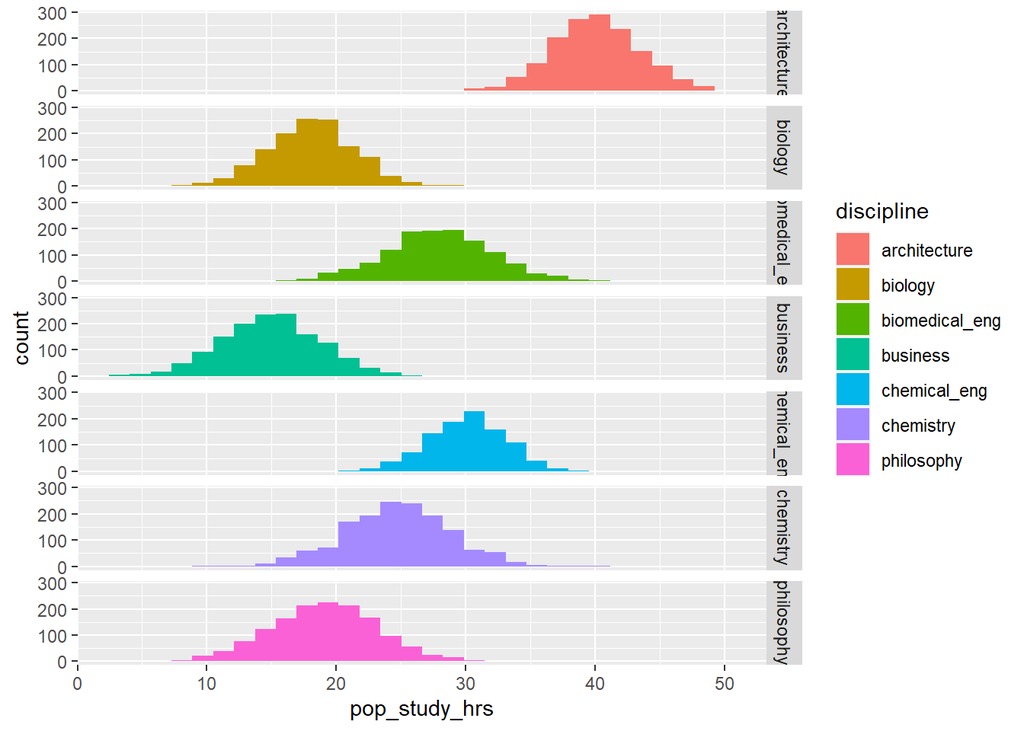

```r
pop_data_df %>%
  ggplot(aes(x = pop_study_hrs, fill = discipline)) +
  geom_histogram() +
  facet_grid(discipline ~ .)
```

Draw samples from populations

```r
samp_n <- c(50, 60, 65, 35, 50, 45, 70)

samp_size_arc <- 50
samp_size_bio <- 60
samp_size_bme <- 65
samp_size_cheg <- 35
samp_size_bus <- 50
samp_size_phi <- 45
samp_size_chem <- 70


samp_arc_df <- pop_data_df %>%
  filter(discipline == "architecture") %>%
  sample_n(samp_size_arc)

samp_bio_df <- pop_data_df %>%
  filter(discipline == "biology") %>%
  sample_n(samp_size_bio)

samp_bme_df <- pop_data_df %>%
  filter(discipline == "biomedical_eng") %>%
  sample_n(samp_size_bme)

samp_bus_df <- pop_data_df %>%
  filter(discipline == "business") %>%
  sample_n(samp_size_bus)

samp_cheg_df <- pop_data_df %>%
  filter(discipline == "chemical_eng") %>%
  sample_n(samp_size_cheg)

samp_chem_df <- pop_data_df %>%
  filter(discipline == "chemistry") %>%
  sample_n(samp_size_chem)

samp_phi_df <- pop_data_df %>%
  filter(discipline == "philosophy") %>%
  sample_n(samp_size_phi)


# combine the sample dfs into one main data df
data_gen_df <- bind_rows(list(samp_arc_df, samp_bio_df, samp_bme_df, samp_bus_df, samp_cheg_df, samp_chem_df, samp_phi_df))


# rename pop_study_hrs to study_hrs
data_gen_df <- data_gen_df %>% rename(study_hrs = pop_study_hrs)

# round the study_hrs to one decimal place
data_gen_df <- data_gen_df %>%
  mutate(study_hrs = round(study_hrs, 1))
```

Visualize the data

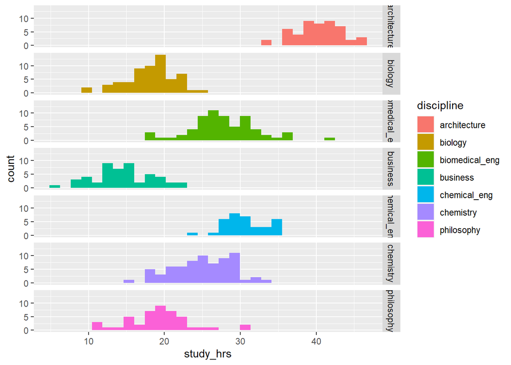

```r
data_gen_df %>%
  ggplot(aes(x = study_hrs, fill = discipline)) +
  geom_histogram() +
  facet_grid(discipline ~ .)
```

We could also look at first-year, second-year, third-year, and fourth-year. This would mean that we have a second factor with four levels.

With the data that we have, we will now do some exploratory work (mostly visualizing and looking at descriptive statistics)

```r
describe(data_gen_df)
```

```
##               vars   n  mean   sd median trimmed  mad  min  max range  skew
## discipline*      1 375   NaN   NA     NA     NaN   NA  Inf -Inf  -Inf    NA
## pop_disc_mean    2 375 24.81 7.71   25.0   24.15 8.90 15.0 40.0  25.0  0.62
## pop_disc_sd      3 375  3.68 0.39    3.8    3.72 0.44  3.0  4.1   1.1 -0.53
## study_hrs        4 375 24.85 8.66   24.1   24.40 8.60  5.8 46.2  40.4  0.41
##               kurtosis   se
## discipline*         NA   NA
## pop_disc_mean    -0.49 0.40
## pop_disc_sd      -1.36 0.02
## study_hrs        -0.49 0.45
```

To look at output by level of the discipline factor Method 1: use describe.by() from the psych package

```r
describe.by(x = data_gen_df, group = "discipline")
```

```
##
##  Descriptive statistics by group
## discipline: architecture
##               vars  n  mean   sd median trimmed  mad  min  max range  skew
## discipline*      1 50   NaN   NA     NA     NaN   NA  Inf -Inf  -Inf    NA
## pop_disc_mean    2 50 40.00 0.00   40.0   40.00 0.00 40.0 40.0   0.0   NaN
## pop_disc_sd      3 50  3.40 0.00    3.4    3.40 0.00  3.4  3.4   0.0   NaN
## study_hrs        4 50 40.23 2.97   40.2   40.25 2.67 33.5 46.2  12.7 -0.14
##               kurtosis   se
## discipline*         NA   NA
## pop_disc_mean      NaN 0.00
## pop_disc_sd        NaN 0.00
## study_hrs        -0.51 0.42
## ------------------------------------------------------------
## discipline: biology
##               vars  n mean   sd median trimmed  mad  min  max range  skew
## discipline*      1 60  NaN   NA     NA     NaN   NA  Inf -Inf  -Inf    NA
## pop_disc_mean    2 60 18.0 0.00   18.0    18.0 0.00 18.0 18.0   0.0   NaN
## pop_disc_sd      3 60  3.2 0.00    3.2     3.2 0.00  3.2  3.2   0.0   NaN
## study_hrs        4 60 18.1 3.21   18.6    18.3 2.82  9.7 24.4  14.7 -0.52
##               kurtosis   se
## discipline*         NA   NA
## pop_disc_mean      NaN 0.00
## pop_disc_sd        NaN 0.00
## study_hrs        -0.01 0.41
## ------------------------------------------------------------
## discipline: biomedical_eng
##               vars  n  mean   sd median trimmed  mad  min  max range skew
## discipline*      1 65   NaN   NA     NA     NaN   NA  Inf -Inf  -Inf   NA
## pop_disc_mean    2 65 28.00 0.00   28.0   28.00 0.00 28.0 28.0   0.0  NaN
## pop_disc_sd      3 65  4.00 0.00    4.0    4.00 0.00  4.0  4.0   0.0  NaN
## study_hrs        4 65 27.71 4.52   27.5   27.66 4.15 17.7 41.2  23.5 0.19
##               kurtosis   se
## discipline*         NA   NA
## pop_disc_mean      NaN 0.00
## pop_disc_sd        NaN 0.00
## study_hrs         0.48 0.56
## ------------------------------------------------------------
## discipline: business
##               vars  n  mean   sd median trimmed  mad  min  max range  skew
```

[output cut: 30 more lines]

```
## pop_disc_mean      NaN 0.00
## pop_disc_sd        NaN 0.00
## study_hrs        -0.52 0.47
## ------------------------------------------------------------
## discipline: philosophy
##               vars  n  mean   sd median trimmed  mad  min  max range skew
## discipline*      1 45   NaN   NA     NA     NaN   NA  Inf -Inf  -Inf   NA
## pop_disc_mean    2 45 19.00 0.00   19.0   19.00 0.00 19.0 19.0   0.0  NaN
## pop_disc_sd      3 45  4.10 0.00    4.1    4.10 0.00  4.1  4.1   0.0  NaN
## study_hrs        4 45 19.29 4.23   19.5   19.14 2.97 11.0 31.3  20.3 0.46
##               kurtosis   se
## discipline*         NA   NA
## pop_disc_mean      NaN 0.00
## pop_disc_sd        NaN 0.00
## study_hrs         0.89 0.63
```

Method 2: use summarize() from tidyverse to create a much sparser version with only select descriptive stats

```r
data_gen_df %>%
  group_by(discipline) %>%
  summarize(n = n(),
            mean = mean(study_hrs),
            sd = sd(study_hrs))
```

```
## # A tibble: 7 x 4
##   discipline         n  mean    sd
##   <chr>          <int> <dbl> <dbl>
## 1 architecture      50  40.2  2.97
## 2 biology           60  18.1  3.21
## 3 biomedical_eng    65  27.7  4.52
## 4 business          50  14.6  3.79
## 5 chemical_eng      35  30.6  2.75
## 6 chemistry         70  25.0  3.97
## 7 philosophy        45  19.3  4.23
```

Visualize the outcome variable distribution

Method 1: histogram

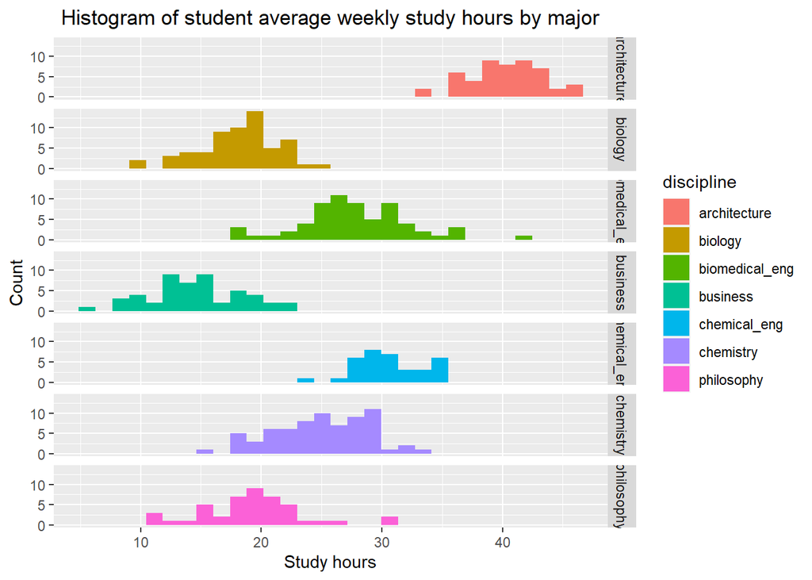

```r
data_gen_df %>%
  ggplot(aes(x = study_hrs, fill = discipline)) +
  geom_histogram() +
  facet_grid(discipline ~ .) +
  labs(title = "Histogram of student average weekly study hours by major",
       x ="Study hours",
       y = "Count") +
  theme(plot.title = element_text(hjust = 0.5))
```

Method 2: boxplots

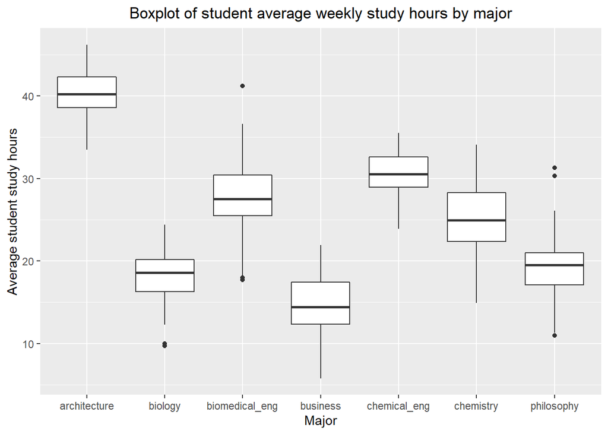

```r
data_gen_df %>%
  ggplot(aes(x = discipline, y = study_hrs)) +
  geom_boxplot() +
  labs(title = "Boxplot of student average weekly study hours by major",
       x ="Major",
       y = "Average student study hours") +
  theme(plot.title = element_text(hjust = 0.5))
```

### Running ANOVA model

Now we can run the ANOVA model using `aov()`

```r
study_hrs_aov <- aov(study_hrs ~ discipline, data = data_gen_df)
summary(study_hrs_aov)
```

```
##              Df Sum Sq Mean Sq F value Pr(>F)
## discipline    6  22881    3813   270.7 <2e-16 ***
## Residuals   368   5184      14
## ---
## Signif. codes:  0 '***' 0.001 '**' 0.01 '*' 0.05 '.' 0.1 ' ' 1
```

### Assumption checks

We should check assumptions of the model

#### Homogeneity of variance (levene’s test)

To test for homogeneity of variancy, we can make boxplots to quickly visualize use plot(model) to see residuals vs fitted plot (as on p. 441) and use Levene’s Test

```r
#leveneTest()
```

#### Welch’s test for heterogeneous variances across groups

```r
#oneway.test()
```

### post hoc comparisons —-

#### Bonferroni; Holm

```r
#pairwise.t.test(p.adjust.method = "bonferroni")
```

#### Tukey and Dunnett

```r
#glht()
```

## Aside: Generating random numbers from various distributions

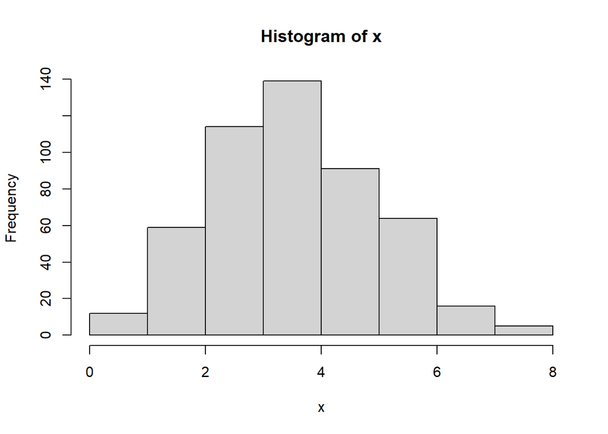

```r
x <- rbinom(n = 500, size = 8, prob = 0.5)
hist(x)
```

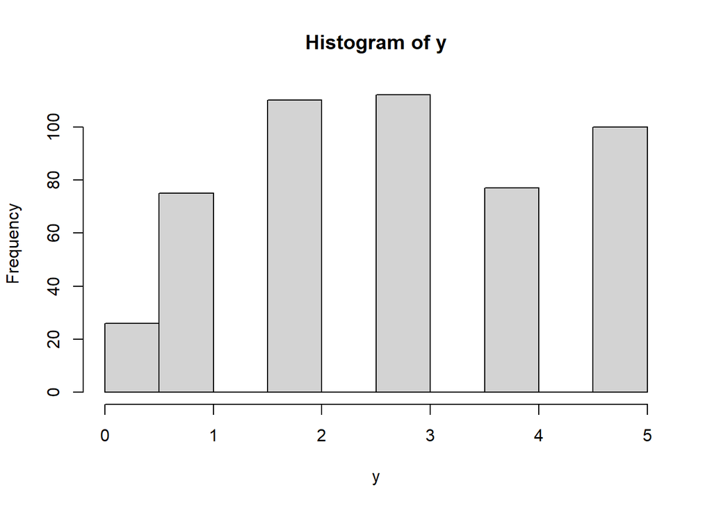

```r
y <- pmin(rpois(n = 500, lambda = 3), 5)
hist(y)
```

```r
samp_tib <- tibble(x = round(rnorm(n = 50, mean = 3, sd = 2), 1),
                   y = round(runif(n = 50, min = 5, max = 15), 1))


total_samples <- 30

samp_size_1 <- 10

samp_size_2 <- 11

samp_size_3 <- 9

samp_idx <- sample(x = length(samp_tib$x), size = total_samples, replace = FALSE)

tot_samp_tib <- samp_tib[samp_idx, ]

samp_tib_1 <- tot_samp_tib[1:samp_size_1, ]

samp_tib_2 <- tot_samp_tib[(samp_size_1+1):(samp_size_2+samp_size_1), ]

samp_tib_3 <- tot_samp_tib[(total_samples-samp_size_3+1):total_samples,]


sample(10, size = 2, replace = FALSE)
```

```
## [1] 9 7
```

```r
income_options <- c("below_20", "20_to_40", "40_to_100", "greater_100")
income <- factor(sample(income_options, 100, TRUE),
                 levels = income_options, ordered = TRUE)

mean_ls <- c(30, 60, 70, 75)
ls <- mean_ls[income] + rnorm(100, sd = 7)
dat <- data.frame(income, ls)
```